# Employee Attrition Modeling: KNN vs Naive Bayes

Nicholas Vandra

2025-10-26

# 1 Introduction

This report reproduces and documents a complete end-to-end classification workflow to predict employee **Attrition** using two classifiers: **K-Nearest Neighbors (KNN)** and **Naive Bayes (NB)**. The analysis follows these stages:

1. Data loading and cleaning
2. Exploratory Data Analysis (EDA): class balance, missing data, demographics, correlations
3. Train/validation split and preprocessing
4. Model training (KNN, Naive Bayes)
5. Threshold calibration and metrics (Accuracy, Sensitivity, Specificity, ROC AUC)
6. Comparative evaluation and visualization (ROC curves)
7. (Optional) Logistic Regression for feature importance/interpretability

All code is built on the **tidyverse/tidymodels** ecosystem and uses your original variable names and transformations.

# 2 Libraries & Global Options

```r
library(tidyverse)
library(tidymodels)
library(data.table)
library(janitor)
library(GGally)
library(vip)
library(performance)
library(probably)
library(finetune)
library(themis)
library(kableExtra)
library(skimr)
library(pROC)
library(corrplot)
library(reshape2)
library(ggthemes)
library(discrim)
library(kknn)
library(naivebayes)
library(broom)
library(dplyr)
library(ggplot2)
library(yardstick)

theme_set(theme_minimal(base_size = 12))
tidymodels_prefer()
```

> **Note:** If any package is missing, install it via `install.packages('package_name')` (or for tidymodels add-ons, check CRAN).

# 3 Parameters & File Paths

These parameters are preserved from your script for transparency and reproducibility.

```r
last_name      <- "Vandra"
incentive_cost <- 200
min_sens       <- 0.60
min_spec       <- 0.60
replacement_factor <- 1.00

train_path <- "C:/Users/nicva/OneDrive/Desktop/Doing Data Science/Project 1/Data/CaseStudy1-data.csv"
comp_path  <- "C:/Users/nicva/OneDrive/Desktop/Doing Data Science/Project 1/Data/CaseStudy1CompSet No Attrition.csv"
id_col_raw <- "ID"
target_col <- "Attrition"

# For convenience after clean_names()
id_col    <- tolower(id_col_raw)   # "id"
targetcol <- tolower(target_col)   # "attrition"
```

# 4 Data Loading & Initial Cleaning

```r
# Load and clean dataset
train_raw <- readr::read_csv(train_path, show_col_types = FALSE) %>% janitor::clean_names()
comp_raw  <- readr::read_csv(comp_path,  show_col_types = FALSE) %>% janitor::clean_names()

# Helper Function: re-level the outcome so positive class Yes is first
as_pos_class <- function(x) forcats::fct_relevel(factor(x), "Yes", "No")

# Apply to training data
train_df <- train_raw %>%
  mutate(!!targetcol := as_pos_class(.data[[targetcol]]))

# Quick schema overview
skimr::skim(train_df)
```

Data summary

| Name | train_df |
| --- | --- |
| Number of rows | 870 |
| Number of columns | 36 |
| _______________________ |  |
| Column type frequency: |  |
| character | 8 |
| factor | 1 |
| numeric | 27 |
| ________________________ |  |
| Group variables | None |

**Variable type: character**

| skim_variable | n_missing | complete_rate | min | max | empty | n_unique | whitespace |
| --- | --- | --- | --- | --- | --- | --- | --- |
| business_travel | 0 | 1 | 10 | 17 | 0 | 3 | 0 |
| department | 0 | 1 | 5 | 22 | 0 | 3 | 0 |
| education_field | 0 | 1 | 5 | 16 | 0 | 6 | 0 |
| gender | 0 | 1 | 4 | 6 | 0 | 2 | 0 |
| job_role | 0 | 1 | 7 | 25 | 0 | 9 | 0 |
| marital_status | 0 | 1 | 6 | 8 | 0 | 3 | 0 |
| over18 | 0 | 1 | 1 | 1 | 0 | 1 | 0 |
| over_time | 0 | 1 | 2 | 3 | 0 | 2 | 0 |

**Variable type: factor**

| skim_variable | n_missing | complete_rate | ordered | n_unique | top_counts |
| --- | --- | --- | --- | --- | --- |
| attrition | 0 | 1 | FALSE | 2 | No: 730, Yes: 140 |

**Variable type: numeric**

| skim_variable | n_missing | complete_rate | mean | sd | p0 | p25 | p50 | p75 | p100 | hist |
| --- | --- | --- | --- | --- | --- | --- | --- | --- | --- | --- |
| id | 0 | 1 | 435.50 | 251.29 | 1 | 218.25 | 435.5 | 652.75 | 870 | ▇▇▇▇▇ |
| age | 0 | 1 | 36.83 | 8.93 | 18 | 30.00 | 35.0 | 43.00 | 60 | ▂▇▇▃▂ |
| daily_rate | 0 | 1 | 815.23 | 401.12 | 103 | 472.50 | 817.5 | 1165.75 | 1499 | ▇▇▇▇▇ |
| distance_from_home | 0 | 1 | 9.34 | 8.14 | 1 | 2.00 | 7.0 | 14.00 | 29 | ▇▅▂▂▂ |
| education | 0 | 1 | 2.90 | 1.02 | 1 | 2.00 | 3.0 | 4.00 | 5 | ▂▅▇▆▁ |
| employee_count | 0 | 1 | 1.00 | 0.00 | 1 | 1.00 | 1.0 | 1.00 | 1 | ▁▁▇▁▁ |
| employee_number | 0 | 1 | 1029.83 | 604.79 | 1 | 477.25 | 1039.0 | 1561.50 | 2064 | ▇▇▇▇▇ |
| environment_satisfaction | 0 | 1 | 2.70 | 1.10 | 1 | 2.00 | 3.0 | 4.00 | 4 | ▅▆▁▇▇ |
| hourly_rate | 0 | 1 | 65.61 | 20.13 | 30 | 48.00 | 66.0 | 83.00 | 100 | ▇▇▆▇▇ |
| job_involvement | 0 | 1 | 2.72 | 0.70 | 1 | 2.00 | 3.0 | 3.00 | 4 | ▁▃▁▇▁ |
| job_level | 0 | 1 | 2.04 | 1.09 | 1 | 1.00 | 2.0 | 3.00 | 5 | ▇▇▃▂▁ |
| job_satisfaction | 0 | 1 | 2.71 | 1.11 | 1 | 2.00 | 3.0 | 4.00 | 4 | ▅▅▁▇▇ |
| monthly_income | 0 | 1 | 6390.26 | 4597.70 | 1081 | 2839.50 | 4945.5 | 8182.00 | 19999 | ▇▅▂▁▁ |
| monthly_rate | 0 | 1 | 14325.62 | 7108.38 | 2094 | 8092.00 | 14074.5 | 20456.25 | 26997 | ▇▇▇▇▇ |
| num_companies_worked | 0 | 1 | 2.73 | 2.52 | 0 | 1.00 | 2.0 | 4.00 | 9 | ▇▃▂▂▁ |
| percent_salary_hike | 0 | 1 | 15.20 | 3.68 | 11 | 12.00 | 14.0 | 18.00 | 25 | ▇▅▃▂▁ |
| performance_rating | 0 | 1 | 3.15 | 0.36 | 3 | 3.00 | 3.0 | 3.00 | 4 | ▇▁▁▁▂ |
| relationship_satisfaction | 0 | 1 | 2.71 | 1.10 | 1 | 2.00 | 3.0 | 4.00 | 4 | ▅▅▁▇▇ |
| standard_hours | 0 | 1 | 80.00 | 0.00 | 80 | 80.00 | 80.0 | 80.00 | 80 | ▁▁▇▁▁ |
| stock_option_level | 0 | 1 | 0.78 | 0.86 | 0 | 0.00 | 1.0 | 1.00 | 3 | ▇▇▁▂▁ |
| total_working_years | 0 | 1 | 11.05 | 7.51 | 0 | 6.00 | 10.0 | 15.00 | 40 | ▇▇▂▁▁ |
| training_times_last_year | 0 | 1 | 2.83 | 1.27 | 0 | 2.00 | 3.0 | 3.00 | 6 | ▂▇▇▂▃ |
| work_life_balance | 0 | 1 | 2.78 | 0.71 | 1 | 2.00 | 3.0 | 3.00 | 4 | ▁▃▁▇▂ |
| years_at_company | 0 | 1 | 6.96 | 6.02 | 0 | 3.00 | 5.0 | 10.00 | 40 | ▇▃▁▁▁ |
| years_in_current_role | 0 | 1 | 4.20 | 3.64 | 0 | 2.00 | 3.0 | 7.00 | 18 | ▇▃▂▁▁ |
| years_since_last_promotion | 0 | 1 | 2.17 | 3.19 | 0 | 0.00 | 1.0 | 3.00 | 15 | ▇▁▁▁▁ |
| years_with_curr_manager | 0 | 1 | 4.14 | 3.57 | 0 | 2.00 | 3.0 | 7.00 | 17 | ▇▂▅▁▁ |

## 4.1 Missing Data Summary

```r
missing_summary <- train_df %>%
  summarise(across(everything(), ~ sum(is.na(.x)))) %>%
  pivot_longer(cols = everything(), names_to = "variable", values_to = "missing") %>%
  mutate(percent_missing = (missing / nrow(train_df)) * 100) %>%
  arrange(desc(percent_missing))

missing_summary %>%
  mutate(missing = scales::comma(missing),
         percent_missing = sprintf("%.2f%%", percent_missing)) %>%
  knitr::kable(caption = "Missing Values by Variable", align = "lrr") %>%
  kableExtra::kable_styling(full_width = FALSE)
```

Missing Values by Variable

| variable | missing | percent_missing |
| --- | --- | --- |
| id | 0 | 0.00% |
| age | 0 | 0.00% |
| attrition | 0 | 0.00% |
| business_travel | 0 | 0.00% |
| daily_rate | 0 | 0.00% |
| department | 0 | 0.00% |
| distance_from_home | 0 | 0.00% |
| education | 0 | 0.00% |
| education_field | 0 | 0.00% |
| employee_count | 0 | 0.00% |
| employee_number | 0 | 0.00% |
| environment_satisfaction | 0 | 0.00% |
| gender | 0 | 0.00% |
| hourly_rate | 0 | 0.00% |
| job_involvement | 0 | 0.00% |
| job_level | 0 | 0.00% |
| job_role | 0 | 0.00% |
| job_satisfaction | 0 | 0.00% |
| marital_status | 0 | 0.00% |
| monthly_income | 0 | 0.00% |
| monthly_rate | 0 | 0.00% |
| num_companies_worked | 0 | 0.00% |
| over18 | 0 | 0.00% |
| over_time | 0 | 0.00% |
| percent_salary_hike | 0 | 0.00% |
| performance_rating | 0 | 0.00% |
| relationship_satisfaction | 0 | 0.00% |
| standard_hours | 0 | 0.00% |
| stock_option_level | 0 | 0.00% |
| total_working_years | 0 | 0.00% |
| training_times_last_year | 0 | 0.00% |
| work_life_balance | 0 | 0.00% |
| years_at_company | 0 | 0.00% |
| years_in_current_role | 0 | 0.00% |
| years_since_last_promotion | 0 | 0.00% |
| years_with_curr_manager | 0 | 0.00% |

## 4.2 Class Distribution

```r
class_dist <- train_df %>%
  count(.data[[targetcol]]) %>%
  mutate(percent = n / sum(n) * 100)

class_dist %>%
  mutate(percent = sprintf("%.1f%%", percent)) %>%
  knitr::kable(caption = "Attrition Class Distribution", align = "lrr") %>%
  kableExtra::kable_styling(full_width = FALSE)
```

Attrition Class Distribution

| attrition | n | percent |
| --- | --- | --- |
| Yes | 140 | 16.1% |
| No | 730 | 83.9% |

# 5 Exploratory Data Analysis (EDA)

## 5.1 Dataset Completeness

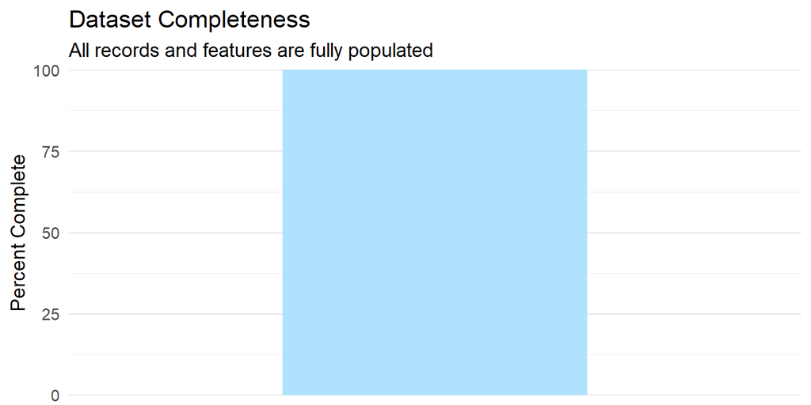

```r
total_missing  <- sum(missing_summary$missing)
total_features <- nrow(missing_summary)
total_cells    <- nrow(train_df) * total_features
pct_complete   <- 100 * (1 - total_missing / total_cells)

ggplot(data.frame(Completeness = pct_complete), aes(x = "Data", y = Completeness)) +
  geom_col(fill = "lightskyblue1", width = 0.5) +
  geom_text(aes(label = paste0(round(Completeness, 1), "% Complete")),
            vjust = -0.5, size = 5, fontface = "bold", color = "#4B0082") +
  scale_y_continuous(limits = c(0, 100), expand = c(0, 0)) +
  labs(
    title = "Dataset Completeness",
    subtitle = "All records and features are fully populated",
    x = NULL, y = "Percent Complete"
  ) +
  theme_minimal(base_size = 14) +
  theme(axis.text.x = element_blank(),
        axis.ticks.x = element_blank(),
        panel.grid.major.x = element_blank())
```

## 5.2 Attrition Distribution

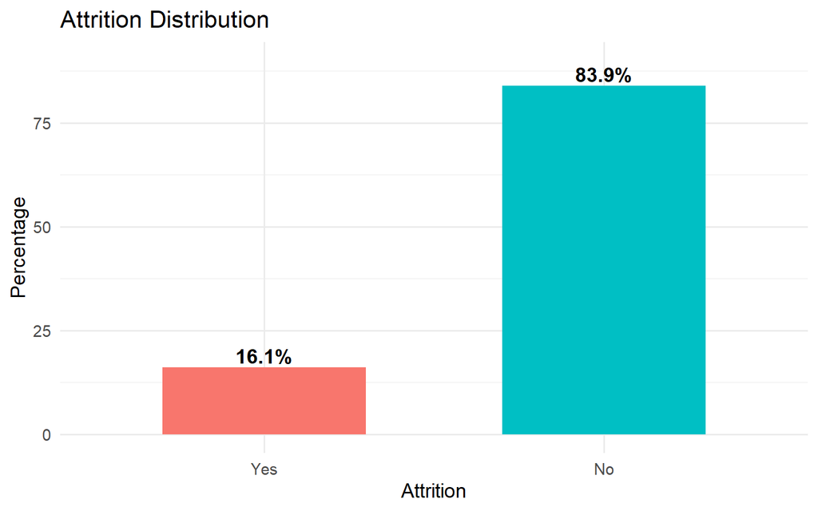

```r
train_df %>%
  count(attrition) %>%
  mutate(percent = n / sum(n) * 100) %>%
  ggplot(aes(x = attrition, y = percent, fill = attrition)) +
  geom_col(width = 0.6) +
  geom_text(aes(label = paste0(round(percent, 1), "%")),
            vjust = -0.3, size = 5, fontface = "bold", color = "black") +
  scale_y_continuous(limits = c(0, 90)) +
  scale_fill_manual(values = c("#F8766D", "#00BFC4")) +
  labs(title = "Attrition Distribution", x = "Attrition", y = "Percentage") +
  theme_minimal(base_size = 14) +
  theme(legend.position = "none")
```

## 5.3 Demographics

### 5.3.1 Age by Attrition

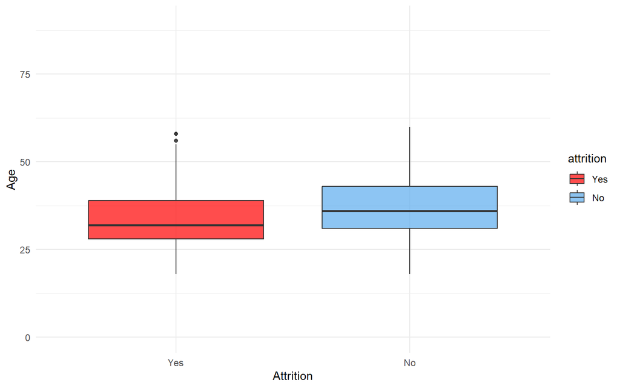

```r
train_df %>%
  ggplot(aes(x = attrition, y = age, fill = attrition)) +
  geom_boxplot(alpha = 0.7) +
  labs(x = "Attrition", y = "Age") +
  scale_y_continuous(limits = c(0, 90)) +
  scale_fill_manual(values = c("red1", "steelblue2")) +
  theme_minimal()
```

### 5.3.2 Education vs Attrition

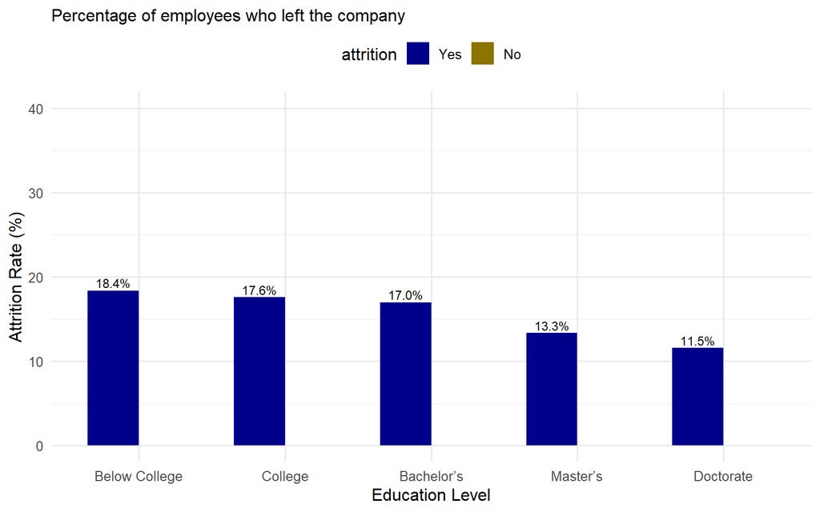

```r
train_df %>%
  group_by(education, attrition) %>%
  summarise(count = n(), .groups = "drop") %>%
  group_by(education) %>%
  mutate(percent = count / sum(count) * 100) %>%
  ungroup() %>%
  mutate(
    education = factor(
      education,
      levels = c(1, 2, 3, 4, 5),
      labels = c("Below College","College","Bachelor’s","Master’s","Doctorate")
    )
  ) %>%
  ggplot(aes(x = education, y = percent, fill = attrition)) +
  geom_col(position = "dodge", width = 0.7) +
  geom_text(aes(label = sprintf("%.1f%%", percent)),
            position = position_dodge(width = 0.7),
            vjust = -0.3, size = 3) +
  scale_fill_manual(values = c("Yes" = "blue4", "No" = "gold4")) +
  labs(subtitle = "Percentage of employees who left the company",
       x = "Education Level", y = "Attrition Rate (%)") +
  theme_minimal(base_size = 12) +
  theme(legend.position = "top") +
  ylim(0, 40)
```

### 5.3.3 Monthly Income vs Attrition

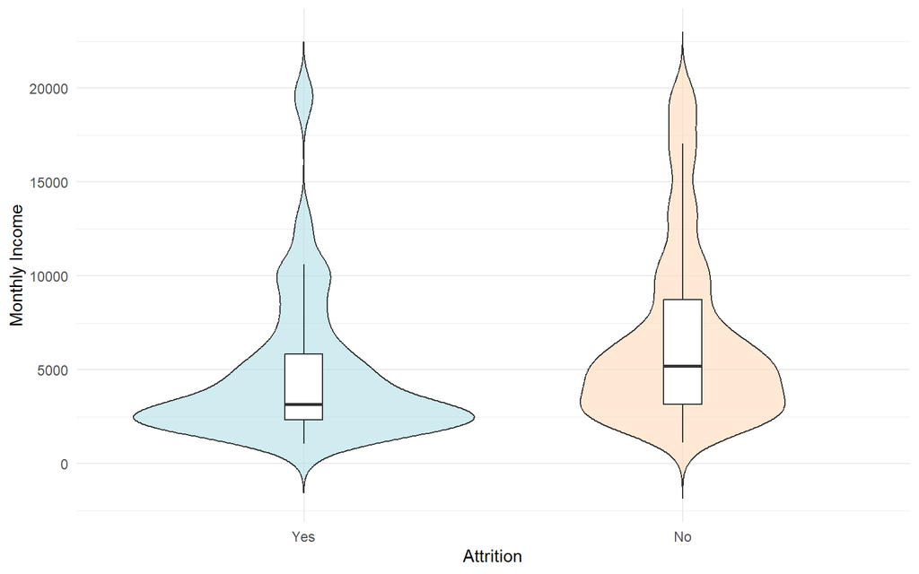

```r
train_df %>%
  ggplot(aes(x = attrition, y = monthly_income, fill = attrition)) +
  geom_violin(trim = FALSE, alpha = 0.6) +
  geom_boxplot(width = 0.1, fill = "white", outlier.shape = NA) +
  scale_fill_manual(values = c("powderblue", "peachpuff")) +
  labs(x = "Attrition", y = "Monthly Income") +
  theme_minimal() +
  theme(legend.position = "none")
```

### 5.3.4 Job Level vs Attrition

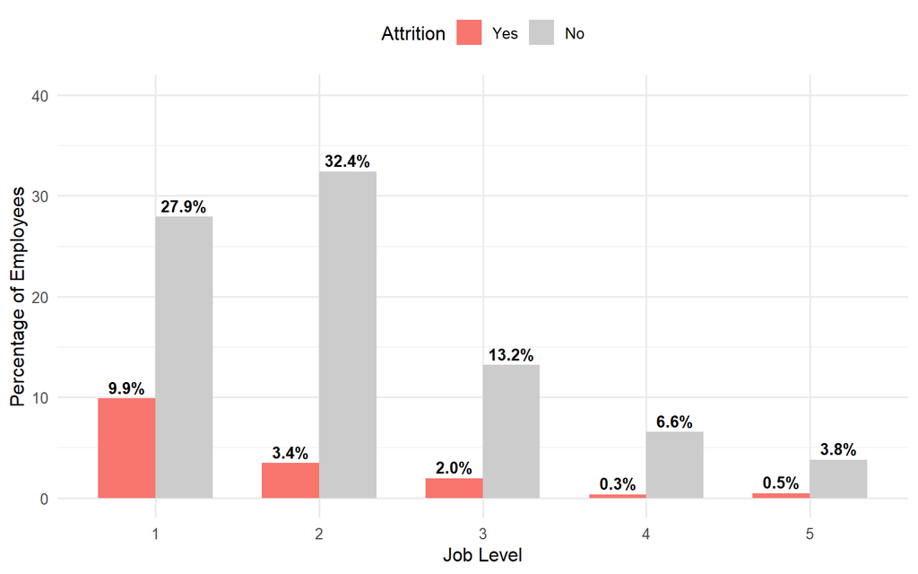

```r
train_df %>%
  group_by(job_level, attrition) %>%
  summarise(count = n(), .groups = "drop") %>%
  mutate(percent = count / sum(count) * 100) %>%
  ggplot(aes(x = factor(job_level), y = percent, fill = attrition)) +
  geom_col(position = "dodge", width = 0.7) +
  geom_text(aes(label = sprintf("%.1f%%", percent)),
            position = position_dodge(width = 0.7),
            vjust = -0.4, size = 3.5, fontface = "bold") +
  scale_fill_manual(values = c("Yes" = "#F8766D", "No" = "gray80"),
                    name = "Attrition") +
  labs(x = "Job Level", y = "Percentage of Employees") +
  theme_minimal(base_size = 12) +
  theme(legend.position = "top") +
  ylim(0, 40)
```

### 5.3.5 Distance from Home (Average) by Attrition

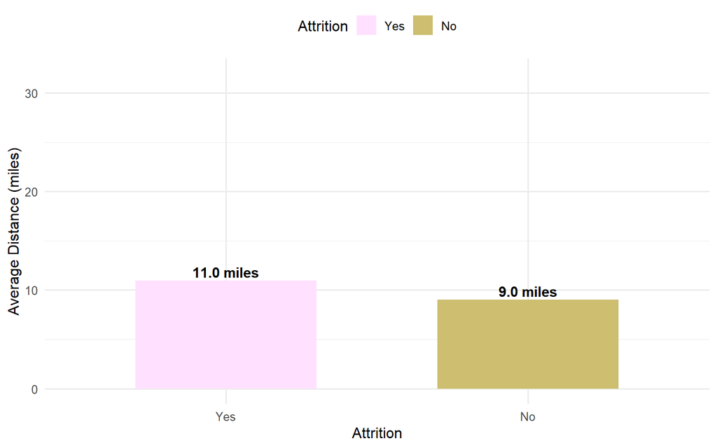

```r
train_df %>%
  group_by(attrition) %>%
  summarise(avg_distance = mean(distance_from_home, na.rm = TRUE)) %>%
  ggplot(aes(x = attrition, y = avg_distance, fill = attrition)) +
  geom_col(width = 0.6) +
  geom_text(aes(label = sprintf("%.1f miles", avg_distance)),
            vjust = -0.3, fontface = "bold", size = 4) +
  scale_fill_manual(values = c("Yes" = "thistle1", "No" = "lightgoldenrod3"),
                    name = "Attrition") +
  labs(x = "Attrition", y = "Average Distance (miles)") +
  theme_minimal(base_size = 12) +
  theme(legend.position = "top") +
  ylim(0, max(train_df$distance_from_home, na.rm = TRUE) * 1.1)
```

### 5.3.6 Job Role vs Attrition

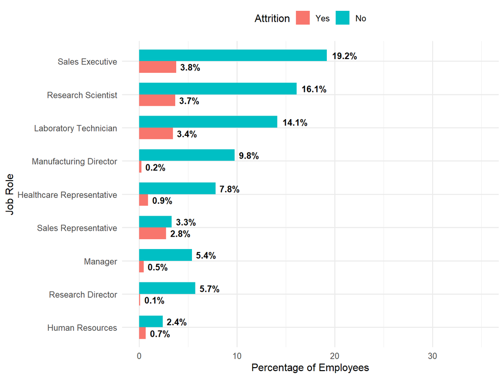

```r
train_df %>%
  group_by(job_role, attrition) %>%
  summarise(count = n(), .groups = "drop") %>%
  mutate(percent = count / sum(count) * 100) %>%
  ggplot(aes(x = reorder(job_role, percent), y = percent, fill = attrition)) +
  geom_col(position = "dodge", width = 0.7) +
  geom_text(aes(label = sprintf("%.1f%%", percent)),
            position = position_dodge(width = 0.7),
            hjust = -0.2, size = 3.5, fontface = "bold") +
  coord_flip() +
  scale_fill_manual(values = c("Yes" = "#F8766D", "No" = "#00BFC4"),
                    name = "Attrition") +
  labs(x = "Job Role", y = "Percentage of Employees") +
  theme_minimal(base_size = 12) +
  theme(legend.position = "top") +
  ylim(0, 35)
```

### 5.3.7 Overtime vs Attrition

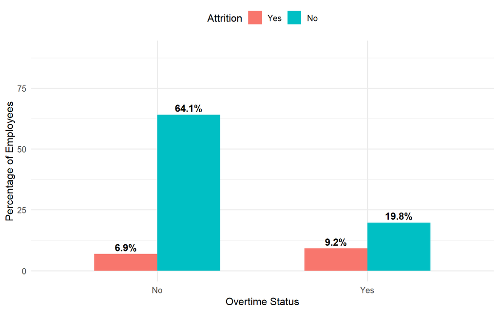

```r
train_df %>%
  group_by(over_time, attrition) %>%
  summarise(count = n(), .groups = "drop") %>%
  mutate(percent = count / sum(count) * 100) %>%
  ggplot(aes(x = over_time, y = percent, fill = attrition)) +
  geom_col(position = "dodge", width = 0.6) +
  geom_text(aes(label = sprintf("%.1f%%", percent)),
            position = position_dodge(width = 0.6),
            vjust = -0.4, size = 4, fontface = "bold") +
  scale_fill_manual(values = c("Yes" = "#F8766D", "No" = "#00BFC4"), name = "Attrition") +
  labs(x = "Overtime Status", y = "Percentage of Employees") +
  theme_minimal(base_size = 12) +
  theme(legend.position = "top") +
  ylim(0, 90)
```

## 5.4 Correlations

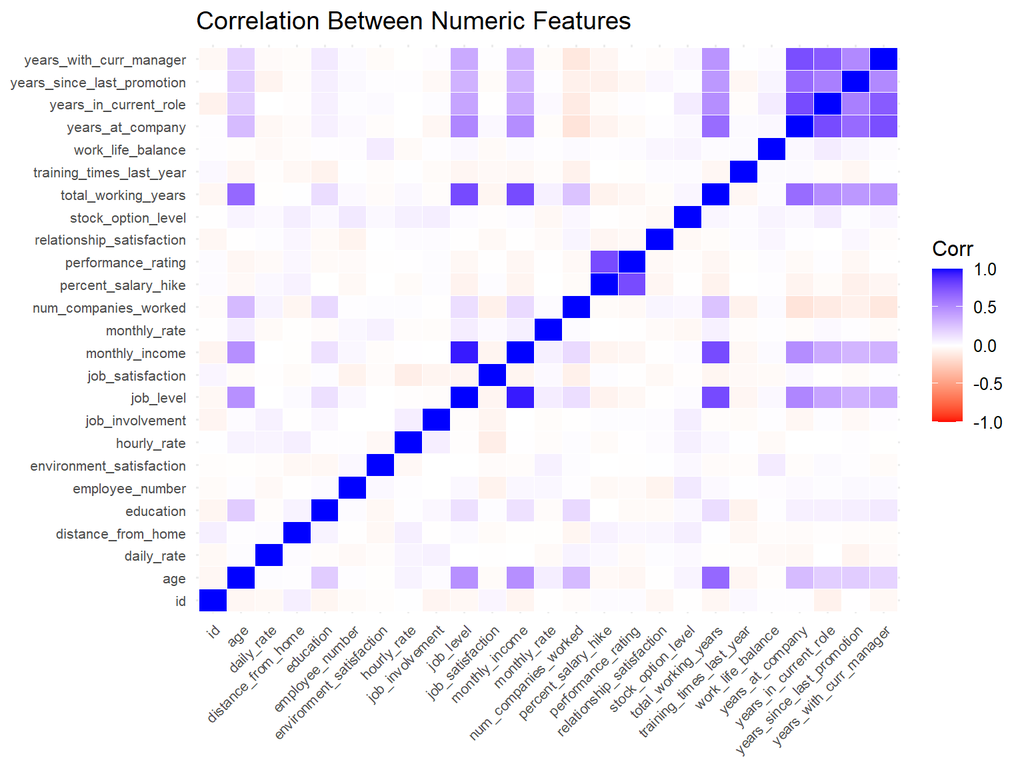

```r
# Select numeric columns with non-zero variance
num_cols <- train_df %>%
  select(where(is.numeric)) %>%
  select(where(~ sd(.x, na.rm = TRUE) > 0)) %>%
  names()

corr_matrix <- cor(train_df[, num_cols], use = "pairwise.complete.obs")
corr_long <- reshape2::melt(corr_matrix)

ggplot(corr_long, aes(x = Var1, y = Var2, fill = value)) +
  geom_tile(color = "white") +
  scale_fill_gradient2(low = "red", mid = "white", high = "blue",
                       midpoint = 0, limit = c(-1,1), name = "Corr") +
  labs(title = "Correlation Between Numeric Features", x = NULL, y = NULL) +
  theme(axis.text.x = element_text(angle = 45, hjust = 1, size = 8),
        axis.text.y = element_text(size = 8))
```

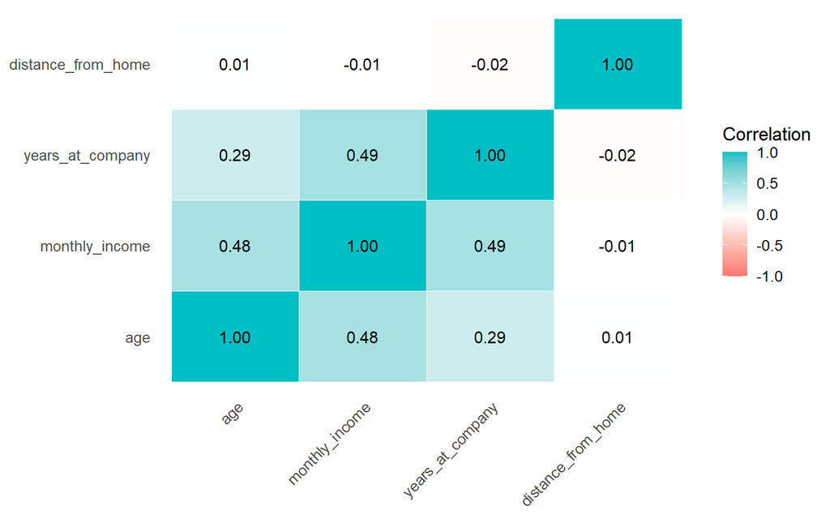

```r
num_vars <- train_df %>%
  select(age, monthly_income, years_at_company, distance_from_home)

corr_mat <- cor(num_vars, use = "pairwise.complete.obs")
corr_long2 <- reshape2::melt(corr_mat)

ggplot(corr_long2, aes(x = Var1, y = Var2, fill = value)) +
  geom_tile(color = "white") +
  geom_text(aes(label = sprintf("%.2f", value)), color = "black", size = 4) +
  scale_fill_gradient2(low = "#F8766D", mid = "white", high = "#00BFC4",
                       midpoint = 0, limits = c(-1, 1), name = "Correlation") +
  labs(x = NULL, y = NULL) +
  theme_minimal(base_size = 13) +
  theme(axis.text.x = element_text(angle = 45, hjust = 1),
        panel.grid = element_blank())
```

# 6 Modeling Pipeline

## 6.1 Train/Validation Split and Cross-Validation

```r
split    <- initial_split(train_df, prop = 0.8, strata = all_of(targetcol))
train    <- training(split)
valid    <- testing(split)
cv_folds <- vfold_cv(train, v = 10, strata = all_of(targetcol))

# Drop ID, Constants, and Leaky Columns
drop_cols <- intersect(c(id_col, "employee_count", "standard_hours", "over18"), names(train))

# Ordinal Integers per Data Dictionary
ordinals <- intersect(c(
  "education","environment_satisfaction","job_involvement","job_satisfaction",
  "performance_rating","relationship_satisfaction","work_life_balance",
  "stock_option_level","job_level"
), names(train))
```

## 6.2 Preprocessing Recipe

All preprocessing steps are included: converting ordinals to factors, removing zero-variance features, imputing missingness, normalizing numerics, one-hot encoding categoricals, and **upsampling** to balance classes in training.

```r
base_recipe <- recipe(
  reformulate(termlabels = setdiff(names(train), c(drop_cols, targetcol)),
              response = targetcol),
  data = train
) %>%
  step_mutate(across(all_of(ordinals), ~ factor(.x))) %>%
  step_zv(all_predictors()) %>%
  step_novel(all_nominal_predictors()) %>%
  step_impute_median(all_numeric_predictors()) %>%
  step_impute_mode(all_nominal_predictors()) %>%
  step_normalize(all_numeric_predictors()) %>%
  step_dummy(all_nominal_predictors(), one_hot = TRUE) %>%
  step_upsample(all_outcomes(), over_ratio = 1)
```

## 6.3 Models & Workflows

```r
# KNN
knn_spec <- nearest_neighbor(
  mode        = "classification",
  neighbors   = 5,
  weight_func = "rectangular"
) %>% set_engine("kknn")

# Naive Bayes (with Laplace smoothing)
nb_spec <- naive_Bayes(mode = "classification", smoothness = 1) %>%
  set_engine("naivebayes")

# Workflows
knn_wf <- workflow() %>% add_model(knn_spec) %>% add_recipe(base_recipe)
nb_wf  <- workflow() %>% add_model(nb_spec)  %>% add_recipe(base_recipe)
```

## 6.4 Fit Models

```r
final_knn <- fit(knn_wf, data = train)
final_nb  <- fit(nb_wf,  data = train)
```

## 6.5 Validation Predictions

```r
pred_knn <- predict(final_knn, valid, type = "prob") %>%
  bind_cols(predict(final_knn, valid, type = "class")) %>%
  rename(pred_class = .pred_class) %>%
  bind_cols(valid %>% select(all_of(targetcol)))

pred_nb <- predict(final_nb, valid, type = "prob") %>%
  bind_cols(predict(final_nb, valid, type = "class")) %>%
  rename(pred_class = .pred_class) %>%
  bind_cols(valid %>% select(all_of(targetcol)))
```

## 6.6 Metrics Helpers

```r
cls_metrics <- metric_set(accuracy, sensitivity, specificity)

summarize_model <- function(pred_df, label){
  core <- cls_metrics(pred_df, truth = .data[[targetcol]], estimate = pred_class,
                      event_level = "first")
  auc  <- roc_auc(pred_df, truth = .data[[targetcol]], .pred_Yes)
  out  <- bind_rows(core, auc) %>% mutate(model = label)
  out
}
```

## 6.7 Validation Metrics at Default Threshold (0.50)

```r
val_knn_50 <- summarize_model(pred_knn, "KNN (0.50)")
val_nb_50  <- summarize_model(pred_nb,  "NB  (0.50)")

bind_rows(val_knn_50, val_nb_50) %>%
  select(model, .metric, .estimate) %>%
  pivot_wider(names_from = .metric, values_from = .estimate) %>%
  mutate(across(-model, ~ round(.x, 3))) %>%
  knitr::kable(caption = "Validation Metrics at 0.50 Threshold") %>%
  kableExtra::kable_styling(full_width = FALSE)
```

Validation Metrics at 0.50 Threshold

| model | accuracy | sensitivity | specificity | roc_auc |
| --- | --- | --- | --- | --- |
| KNN (0.50) | 0.695 | 0.536 | 0.726 | 0.677 |
| NB (0.50) | 0.724 | 0.893 | 0.692 | 0.872 |

## 6.8 Threshold Calibration (Balanced Sensitivity/Specificity)

```r
pick_balanced_threshold <- function(df, truth, prob_col = ".pred_Yes") {
  roc_df <- yardstick::roc_curve(
    df,
    !!rlang::sym(truth),
    !!rlang::sym(prob_col),
    event_level = "first"
  )
  roc_df %>%
    dplyr::mutate(min_ss = pmin(sensitivity, specificity)) %>%
    dplyr::arrange(dplyr::desc(min_ss)) %>%
    dplyr::slice(1) %>%
    dplyr::pull(.threshold)
}

apply_thresh <- function(df, th){
  df %>%
    dplyr::mutate(
      pred_thresh = factor(
        if_else(.pred_Yes >= th, "Yes","No"),
        levels = c("Yes","No")
      )
    )
}
```

```r
th_knn_bal <- pick_balanced_threshold(pred_knn, targetcol)
th_nb_bal  <- pick_balanced_threshold(pred_nb,  targetcol)

pred_knn_t <- apply_thresh(pred_knn, th_knn_bal)
pred_nb_t  <- apply_thresh(pred_nb,  th_nb_bal)

balanced_results <- bind_rows(
  cls_metrics(pred_knn_t, truth = .data[[targetcol]], estimate = pred_thresh,
              event_level = "first") %>%
    mutate(model = sprintf("KNN (th=%.2f)", th_knn_bal)),
  cls_metrics(pred_nb_t,  truth = .data[[targetcol]], estimate = pred_thresh,
              event_level = "first") %>%
    mutate(model = sprintf("NB  (th=%.2f)", th_nb_bal))
)

balanced_results %>%
  select(model, .metric, .estimate) %>%
  pivot_wider(names_from = .metric, values_from = .estimate) %>%
  mutate(across(-model, ~ round(.x, 3))) %>%
  knitr::kable(caption = "Validation Metrics at Balanced Thresholds") %>%
  kableExtra::kable_styling(full_width = FALSE)
```

Validation Metrics at Balanced Thresholds

| model | accuracy | sensitivity | specificity |
| --- | --- | --- | --- |
| KNN (th=0.40) | 0.632 | 0.679 | 0.623 |
| NB (th=0.69) | 0.753 | 0.750 | 0.753 |

## 6.9 ROC Curves & Numerical Comparison

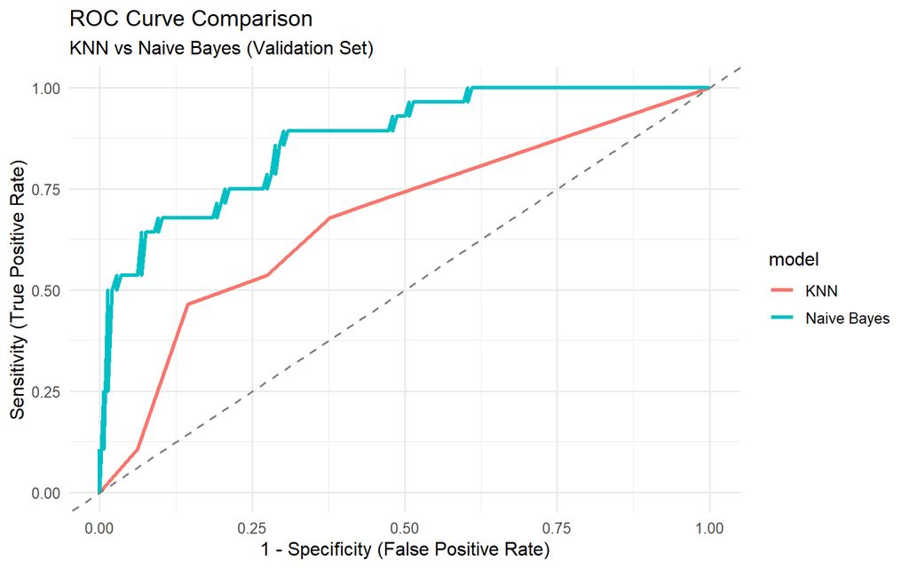

```r
roc_knn <- yardstick::roc_curve(pred_knn, truth = !!rlang::sym(targetcol), .pred_Yes) %>%
  dplyr::mutate(model = "KNN")
roc_nb  <- yardstick::roc_curve(pred_nb,  truth = !!rlang::sym(targetcol), .pred_Yes) %>%
  dplyr::mutate(model = "Naive Bayes")

roc_df <- dplyr::bind_rows(roc_knn, roc_nb)

ggplot(roc_df, aes(x = 1 - specificity, y = sensitivity, color = model)) +
  geom_line(linewidth = 1.2) +
  geom_abline(linetype = "dashed", color = "gray50") +
  labs(title = "ROC Curve Comparison",
       subtitle = "KNN vs Naive Bayes (Validation Set)",
       x = "1 - Specificity (False Positive Rate)",
       y = "Sensitivity (True Positive Rate)")
```

```r
roc_auc_knn <- yardstick::roc_auc(pred_knn, truth = !!rlang::sym(targetcol), .pred_Yes)
roc_auc_nb  <- yardstick::roc_auc(pred_nb,  truth = !!rlang::sym(targetcol), .pred_Yes)

acc_knn  <- yardstick::accuracy(pred_knn, truth = !!rlang::sym(targetcol), estimate = pred_class)
acc_nb   <- yardstick::accuracy(pred_nb,  truth = !!rlang::sym(targetcol), estimate = pred_class)

sens_knn <- yardstick::sensitivity(pred_knn, truth = !!rlang::sym(targetcol), estimate = pred_class)
sens_nb  <- yardstick::sensitivity(pred_nb,  truth = !!rlang::sym(targetcol), estimate = pred_class)

spec_knn <- yardstick::specificity(pred_knn, truth = !!rlang::sym(targetcol), estimate = pred_class)
spec_nb  <- yardstick::specificity(pred_nb,  truth = !!rlang::sym(targetcol), estimate = pred_class)

results_summary <- tibble::tibble(
  Model = c("KNN", "Naive Bayes"),
  Accuracy = c(acc_knn$.estimate,  acc_nb$.estimate),
  Sensitivity = c(sens_knn$.estimate, sens_nb$.estimate),
  Specificity = c(spec_knn$.estimate, spec_nb$.estimate),
  ROC_AUC = c(roc_auc_knn$.estimate, roc_auc_nb$.estimate)
)

results_summary %>%
  mutate(across(-Model, ~ round(.x, 3))) %>%
  knitr::kable(caption = "Model Comparison on Validation Set") %>%
  kableExtra::kable_styling(full_width = FALSE)
```

Model Comparison on Validation Set

| Model | Accuracy | Sensitivity | Specificity | ROC_AUC |
| --- | --- | --- | --- | --- |
| KNN | 0.695 | 0.536 | 0.726 | 0.677 |
| Naive Bayes | 0.724 | 0.893 | 0.692 | 0.872 |

# 7 (Optional) Feature Importance via Logistic Regression

A simple **logistic regression** (GLM) can provide coefficient-based interpretability. This section fits a GLM using the same recipe to understand which predictors are most associated with attrition. (This is **not** used for selection—only for interpretability.)

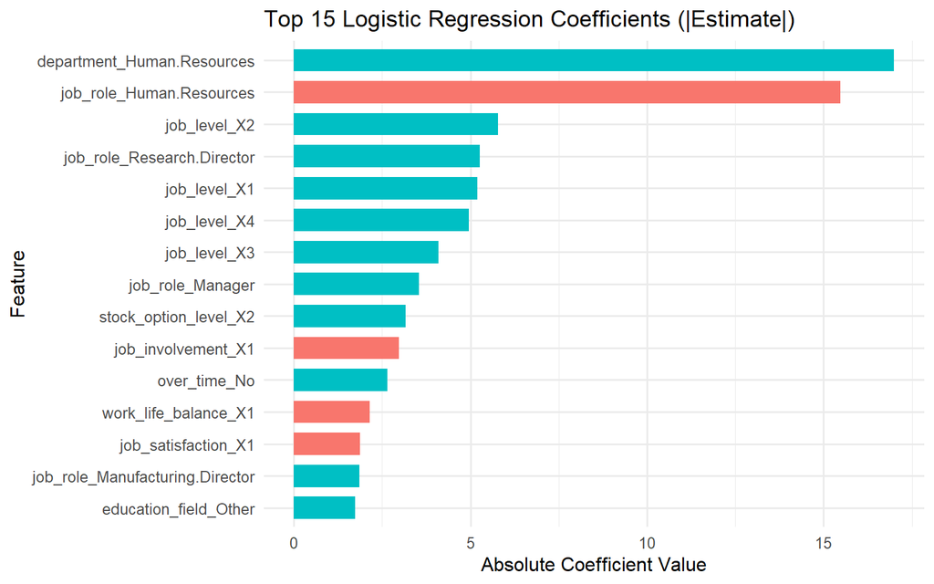

```r
log_spec <- logistic_reg(mode = "classification") %>% set_engine("glm")
log_wf   <- workflow() %>% add_model(log_spec) %>% add_recipe(base_recipe)
log_fit  <- fit(log_wf, data = train)

log_fit_extracted <- extract_fit_parsnip(log_fit)

log_coef <- tidy(log_fit_extracted) %>%
  filter(term != "(Intercept)") %>%
  mutate(abs_estimate = abs(estimate)) %>%
  arrange(desc(abs_estimate)) %>%
  slice(1:15)

ggplot(log_coef, aes(x = reorder(term, abs_estimate), y = abs_estimate, fill = estimate > 0)) +
  geom_col(width = 0.7, show.legend = FALSE) +
  coord_flip() +
  scale_fill_manual(values = c("#F8766D", "#00BFC4")) +
  labs(x = "Feature", y = "Absolute Coefficient Value",
       title = "Top 15 Logistic Regression Coefficients (|Estimate|)")
```

# 8 Conclusions

- Both **KNN** and **Naive Bayes** are trained on a balanced (upsampled) training set and evaluated on a held-out validation set.
- Performance metrics are reported at both the default 0.5 threshold and at **balanced thresholds** that maximize the minimum of sensitivity and specificity.
- The **ROC curves** and table summarize comparative performance; choose the model that best satisfies the business constraints (e.g., minimum sensitivity/specificity of 0.60).
- Coefficient magnitudes from a simple **logistic regression** offer additional interpretability of drivers of attrition.